[figure not shown]

# **PixToPalette: Generate a Custom Color Palette from Your Images**

## **Overview**

PixToPalette is a Shiny application that allows users to upload an image and generate a custom color palette based on the dominant colors in the image. By using k-means clustering, the app identifies the key colors in the image, providing a versatile tool for anyone who needs a tailored color scheme - whether the application be graphic design, informatics or interior design. Users can select the number of colors they want in their palette, ensuring flexibility for various use cases. Hex codes can be easily exported for use or results can be downloaded as a PDF.

### **Inspiration**

The idea for this app originated from my search for a suitable color palette for a work-related dashboard. I wanted a palette that perfectly complemented the dashboard’s cover image. During this search, I came across the [National Park Palette repository](https://github.com/kevinsblake/NatParksPalettes) on GitHub, which inspired me to create a tool to generate custom palettes from any image.

The app’s foundation lies in the principles outlined in an [R-bloggers article](https://www.r-bloggers.com/2018/11/utilizing-k-means-to-extract-colours-from-your-favourite-images/). I refined the code presented in the article to suit my needs and integrated it into a user-friendly Shiny application.

## **Features**

- **Image Upload**: Upload your favorite image (PNG or JPEG format).
- **Color Palette Customization**: Select the number of colors (clusters) for your palette.
- **Interactive Visualization**: View the dominant colors and their proportions in your image.
- **Downloadable Palette**: Save the generated color palette for use in your projects.

## **How It Works**

1. **Image Processing**: The app reads the uploaded image and converts it into a data matrix of pixel values.
2. **K-Means Clustering**: Using k-means clustering, the app groups pixel colors into user-specified clusters.
3. **Palette Generation**: The app extracts the dominant colors and displays them as a palette.
4. **User Interaction**: The user can adjust the number of clusters and regenerate the palette to meet their needs.

## **Installation and Usage**

### **Prerequisites**

- R (>= 4.0.0)
- Shiny package

### **Clone the Repository**

git clone https://github.com/terripietka/PixToPalette.git  
cd PixToPalette

## **Repository Structure**

- `app.R`: Defines the user interface of the app and contains the server-side logic
- `library/`: Contains the functions for image processing, k-means clustering and palette visualization.
- `www/`: Contains assets for styling the app.
- `examples/`: Includes example images for testing.

## **Shiny Link**

You can access the web link for the online app here:

https://terripietka.shinyapps.io/PixToPalette/

## **Examples**

Here are a couple examples of a generated palette from sample images:

1. **Sedona**:

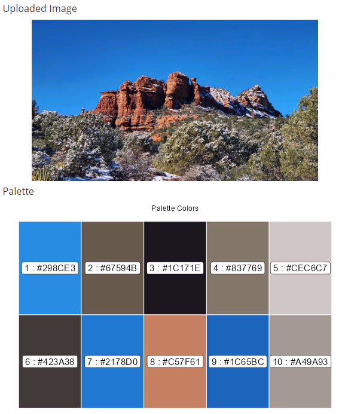

2. **Mount Rainier**:

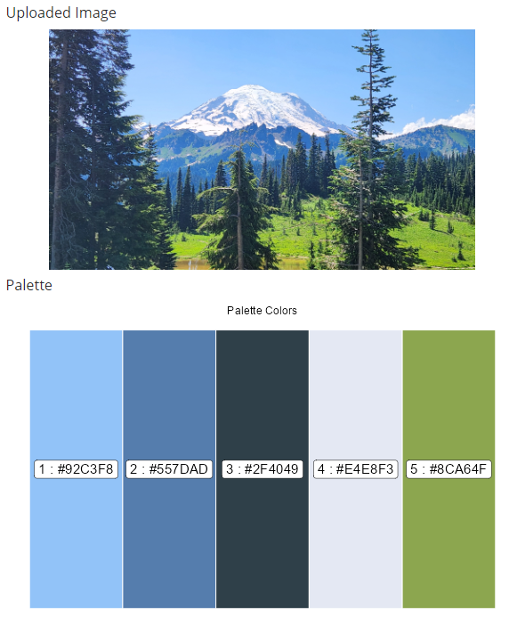

## **License**

This project is licensed under the Apache 2.0 License. See the LICENSE file for details.

## **Credits**

- [National Park Palette](https://github.com/kevinsblake/NatParksPalettes) for inspiration.
- [R-bloggers](https://www.r-bloggers.com/2018/11/utilizing-k-means-to-extract-colours-from-your-favourite-images/) for the foundational k-means clustering code.

## **Contributing**

Contributions are welcome! Feel free to open an issue or submit a pull request if you have ideas for new features or improvements.

## **Contact**

If you have any questions or suggestions, feel free to contact me at terripietka@gmail.com